# HDPBO学习笔记

**Hsiang. 2021.11**

## 一、环境

### 1.1 环境要求

1. Ubuntu >= 18.04
2. NVIDIA GPU(s) with Linux x86_64 driver version >= 418.39 (compatible with CUDA 10.1)
3. Python >= 3.6
4. TensorFlow 2.1
5. TensorFlow Probability 0.9
6. GPflow 2.0.0-rc1
7. CUDA 10.1
8. cuDNN 7.6.5
9. Matplotlib

### 1.2 环境检查

```python
!cat /proc/version
```

```
Linux version 5.11.0-40-generic (buildd@lgw01-amd64-010) (gcc (Ubuntu 9.3.0-17ubuntu1~20.04) 9.3.0, GNU ld (GNU Binutils for Ubuntu) 2.34) #44~20.04.2-Ubuntu SMP Tue Oct 26 18:07:44 UTC 2021
```

```python
!nvidia-smi
```

```
Fri Nov 26 13:56:44 2021
+-----------------------------------------------------------------------------+
| NVIDIA-SMI 495.44       Driver Version: 495.44       CUDA Version: 11.5     |
|-------------------------------+----------------------+----------------------+
| GPU  Name        Persistence-M| Bus-Id        Disp.A | Volatile Uncorr. ECC |
| Fan  Temp  Perf  Pwr:Usage/Cap|         Memory-Usage | GPU-Util  Compute M. |
|                               |                      |               MIG M. |
|===============================+======================+======================|
|   0  NVIDIA GeForce ...  Off  | 00000000:01:00.0  On |                  N/A |
| N/A   77C    P0    29W /  N/A |    395MiB /  6069MiB |      1%      Default |
|                               |                      |                  N/A |
+-------------------------------+----------------------+----------------------+

+-----------------------------------------------------------------------------+
| Processes:                                                                  |
|  GPU   GI   CI        PID   Type   Process name                  GPU Memory |
|        ID   ID                                                   Usage      |
|=============================================================================|
|    0   N/A  N/A      1018      G   /usr/lib/xorg/Xorg                 35MiB |
|    0   N/A  N/A      1607      G   /usr/lib/xorg/Xorg                139MiB |
|    0   N/A  N/A      1812      G   /usr/bin/gnome-shell               28MiB |
|    0   N/A  N/A      2763      G   /usr/lib/firefox/firefox          176MiB |
|    0   N/A  N/A      3385      G   /usr/lib/firefox/firefox            1MiB |
|    0   N/A  N/A      3485      G   /usr/lib/firefox/firefox            1MiB |
|    0   N/A  N/A      3560      G   /usr/lib/firefox/firefox            1MiB |
+-----------------------------------------------------------------------------+
```

```python
!nvcc --version
```

```
nvcc: NVIDIA (R) Cuda compiler driver
Copyright (c) 2005-2021 NVIDIA Corporation
Built on Mon_Sep_13_19:13:29_PDT_2021
Cuda compilation tools, release 11.5, V11.5.50
Build cuda_11.5.r11.5/compiler.30411180_0
```

```python
!conda --version
!python --version
```

```
conda 4.5.11
Python 3.7.0
```

```python
!pip list | grep tensorflow
```

```
tensorflow                         2.7.0
tensorflow-estimator               2.7.0
tensorflow-gpu                     2.7.0
tensorflow-io-gcs-filesystem       0.22.0
tensorflow-probability             0.14.1
```

```python
!pip list | grep GPflow
```

```
gpflow                             2.0.0rc1  /home/hsiang/GPflow
```

```python
!pip list | grep matplotlib
```

```
matplotlib                         3.5.0
```

## 二、准备工作

### 2.1 导入要用的库

```python
import numpy as np
import gpflow
import tensorflow as tf
import tensorflow_probability as tfp
import matplotlib.pyplot as plt
import sys
import os
import datetime
import pickle
import importlib
import scipy.stats as spst
import scipy.special as spmc
from gpflow.utilities import set_trainable, print_summary
```

### 2.2 对当前系统可用GPU的判断

这里利用TF包进行“程序性地判断”

```python
gpu_to_use = 0

# 判断是否有可用的GPU资源
print("Num GPUs Available: ", len(tf.config.experimental.list_physical_devices('GPU')))

gpus = tf.config.experimental.list_physical_devices('GPU')
if gpus:
    # Restrict TensorFlow to only use the first GPU
    try:
        for gpu in gpus:
            tf.config.experimental.set_memory_growth(gpu, True)
        tf.config.experimental.set_visible_devices(gpus[gpu_to_use], 'GPU')
        logical_gpus = tf.config.experimental.list_logical_devices('GPU')
        print(len(gpus), "Physical GPUs,", len(logical_gpus), "Logical GPU")
    except RuntimeError as e:
        # Visible devices must be set before GPUs have been initialized
        print(e)
```

```
Num GPUs Available:  1
1 Physical GPUs, 1 Logical GPU
```

## 三、每轮运行的准备

### 3.1 生成初始点

一共运行10轮，每轮要初始化最开始的3个点，对这3个点进行两两比较，形成3个duels

#### 初始化每轮的观测点

```python
## 初始化数据：得到的这是十次迭代中，每次最初的三个点[x,x']的x的坐标

# 使用numpy按照均匀分布进行初始化数据，存放到init_points
objective_low = 0.      # 均匀分布下界0. （这也是输入x的下界）
objective_high = 1.     # 均匀分布上界1. （这也是输入x的上界）
num_runs = 10           # 运行次数
num_init_points = 3     # 最初要比较的点数
input_dims = 1          # 输入数据的维数，若采用其他obj func，则可改成对应的维数

# 得到的这是十次迭代中，每次最初的三个点[x,x']的x的坐标（这里取的是一维的）
np.random.seed(0)       # 选择随机种子，只要使用相同的种子，那么跑出来的数据就一样
init_points = np.random.uniform(low = objective_low, high = objective_high, size = [num_runs, num_init_points, input_dims])

print(init_points)
```

```
[[[0.5488135 ]
  [0.71518937]
  [0.60276338]]

 [[0.54488318]
  [0.4236548 ]
  [0.64589411]]

 [[0.43758721]
  [0.891773  ]
  [0.96366276]]

 [[0.38344152]
  [0.79172504]
  [0.52889492]]

 [[0.56804456]
  [0.92559664]
  [0.07103606]]

 [[0.0871293 ]
  [0.0202184 ]
  [0.83261985]]

 [[0.77815675]
  [0.87001215]
  [0.97861834]]

 [[0.79915856]
  [0.46147936]
  [0.78052918]]

 [[0.11827443]
  [0.63992102]
  [0.14335329]]

 [[0.94466892]
  [0.52184832]
  [0.41466194]]]
```

```python
## 初始化每一对要比较的[x,x']
# 一共是30对，因为要迭代10次，每一次最开始要比较的点数是3个点

num_choices = 2         # 每次是比较两个点参与比较，即preference是[x,x']（在duels为[x,x']时，其实就不用再考虑这个num_choices了，永远都是2，包括下文都不用再考虑了）
num_combs = int((num_init_points - 1) * num_init_points / 2)    # 初始时是n个点，这n个点之间两两比较，一共生成n(n-1)/2个[x,x']形式的duels

# 初始化这30对duels，先预留好位置，用全0张量记之
init_vals = np.zeros([num_runs, num_combs, num_choices, input_dims])
# print(init_vals)
```

#### 形成duels

```python
## 对刚刚zeros的init_vals张量进行数据的填充，即把init_points的数据填到init_vals中，形成两两比较的duels

# 声明时是四维张量，这里三个for嵌套即可实现
for run in range(num_runs):
    cur_idx = 0
    for init_point in range(num_init_points - 1):
        for next_point in range(init_point + 1, num_init_points):
            init_vals[run, cur_idx, 0] = init_points[run, init_point]
            init_vals[run, cur_idx, 1] = init_points[run, next_point]
            cur_idx += 1

# print(init_vals)
```

```python
## resharp数据，便于后面处理（数据内容还和上面一样）

# 数据变成3维张量，最小的一维是duel，然后是每一轮的3个duels，最后是10轮的数据
init_vals = np.reshape(init_vals, [num_runs, num_combs, num_choices * input_dims])
print(init_vals)
```

```
[[[0.5488135  0.71518937]
  [0.5488135  0.60276338]
  [0.71518937 0.60276338]]

 [[0.54488318 0.4236548 ]
  [0.54488318 0.64589411]
  [0.4236548  0.64589411]]

 [[0.43758721 0.891773  ]
  [0.43758721 0.96366276]
  [0.891773   0.96366276]]

 [[0.38344152 0.79172504]
  [0.38344152 0.52889492]
  [0.79172504 0.52889492]]

 [[0.56804456 0.92559664]
  [0.56804456 0.07103606]
  [0.92559664 0.07103606]]

 [[0.0871293  0.0202184 ]
  [0.0871293  0.83261985]
  [0.0202184  0.83261985]]

 [[0.77815675 0.87001215]
  [0.77815675 0.97861834]
  [0.87001215 0.97861834]]

 [[0.79915856 0.46147936]
  [0.79915856 0.78052918]
  [0.46147936 0.78052918]]

 [[0.11827443 0.63992102]
  [0.11827443 0.14335329]
  [0.63992102 0.14335329]]

 [[0.94466892 0.52184832]
  [0.94466892 0.41466194]
  [0.52184832 0.41466194]]]
```

### 3.2 生成离散化的样本空间

真正进行拟合的样本是[x,x']的形式，所以样本空间是二维平面的点。这里的离散化在[0,1]上均匀取1000个点作为$\mathcal{X}$，然后$\mathcal{X} \times \mathcal{X}$得到一张1000*1000的网格。

```python
## uniform_grid函数：形成在一个区间上的均匀数值（目的是为了将目标函数的定义域连续区间离散化）
# 如：uniform_grid(1, 1000, 0, 1)
# 即：在一维区间[0,1]上均匀生成1000个点

def uniform_grid(input_dims, num_discrete_per_dim, low, high):
    """
    Returns an array with all possible permutations of discrete values in input_dims number of dimensions.
    :param input_dims: int
    :param num_discrete_per_dim: int
    :param low: int
    :param high: int
    :return: tensor of shape (num_discrete_per_dim ** input_dims, input_dims)
    """
    num_points = num_discrete_per_dim ** input_dims
    out = np.zeros([num_points, input_dims])
    discrete_points = np.linspace(low, high, num_discrete_per_dim)
    for i in range(num_points):
        for dim in range(input_dims):
            val = num_discrete_per_dim ** dim
            out[i, dim] = discrete_points[int((i // val) % num_discrete_per_dim)]
    return out
```

```python
## 将目标函数的定义域[objective_low, objective_high]离散化为1000个点，得到discreate_space

num_discrete_per_dim = 1000  # 离散化为1000个点
discrete_space = uniform_grid(input_dims, num_discrete_per_dim, objective_low, objective_high)
# print(discrete_space)
```

```python
## 给出点，conbinations函数返回这些点构成的所有的“两两组合”
# 如：将上一步的均匀分布在[0,1]上的1000个点输入，则返回这1000个点的两两组合1000x1000

def combinations(points):
    """
    Given d-dimensional points, return all pair combinations of those points
    :param points: tensor of shape (n, d)
    :return: tensor of shape (n ** 2, d * 2)
    """
    n = points.shape[0]         # 点的数量
    d = points.shape[1]         # 点的维度

    out = np.zeros((n*n, d*2))     # 初始化输出，按照上面的说明（显然）
    for i in range(n):
        for j in range(n):
            out[i*n+j][0:d] = points[i]      # 一步步给输出赋值
            out[i*n+j][d:d*2] = points[j]
    return out
```

```python
## 返回在定义域[0,1]上1000个均匀分布的点的网格（两两有序组合，不就形成了坐标网格嘛）
combs = combinations(discrete_space)
# print(combs)
```

### 3.3 定义存储结果的数组

```python
num_evals = 20         # 前面定义了一共要跑10轮，这里定义每一轮一共要跑20次迭代

## 每一轮结束时得到的全部数据的数量为num_data_at_end，计算如下
# 在每一轮中，初始化了num_combs对点，迭代num_evals次生成num_evals对点
# 一共(num_combs+num_evals)对点，每对点的x和x'又可以交换，故*2
num_data_at_end = (num_combs + num_evals) * 2

# 初始化输入duels的数据为全0张量：（10轮）x（每轮46个点）x（1维点的[x,x']要存的attribute为1*2=2个）
X_results = np.zeros([num_runs, num_data_at_end, input_dims * num_choices])

# 初始化每个duels的结果为全0张量：对应X_results给出的查询结果：（10轮）x（每轮46个点）x（每个点1个结果）
y_results = np.zeros([num_runs, num_data_at_end, 1])

# 初始化每一轮猜测的最好的点为全0张量：存储每轮每次迭代中给出的预测结果（最佳点）：（10轮）x（每轮20次迭代）x（1为点）
best_guess_results = np.zeros([num_runs, num_evals, input_dims])
```

## 四、每轮优化中对模型的迭代更新：PBO

这里为了方便注释和学习，将代码中的for循环进行了拆解，由上面可以看出，要进行num_runs=10轮运行，每轮中有num_evals次迭代，即每一次迭代和运行的过程是放在两个for循环中间的。

为了方便学习，这里先去掉for循环，逐步了解每一步的意义，在下一章节再放到for循环中进行整体运行。

### 4.1 对目标函数的观测方法

#### 4.1.1 目标函数及相关参数

```python
## 这里选择forrester作为目标函数，下面是对forrester函数的定义
# f(x) = ((6x - 2) ^ 2) * sin(12x - 4)

def forrester(x):
    """
    1-dimensional test function by Forrester et al. (2008)
    Defined as f(x) = (6x-2)^2 * sin(12x-4)
    :param x: tensor of shape (..., 1), x1 in [0, 1]
    :return: tensor of shape (..., )
    """
    x0 = x[..., 0]        # 取出第0列数据（基于numpy的数组）
    return (6 * x0 - 2) * (6 * x0 - 2) * np.sin(12 * x0 - 4)       # 返回函数值
```

```python
## 目标函数的相关参数，方便下面调用
objective = forrester                # 目标函数
objective_low = 0.                   # 定义域下界
objective_high = 1.                  # 定义域上界
```

#### 4.1.2 对目标函数的观测

```python
## 获取目标函数的返回值的相反数（乘-1）
# 函数的返回值是通过np.expand_dims得到的，要注意形式

def objective_get_f_neg(x, objective):
    """
    Get objective function values of inputs. Note that this returns the negative of the above objective functions,
    as observation_model.gen_observation_from_f takes it that more positive functions values are preferred, while we
    are interested in finding the minima of the above functions.
    :param x: tensor of shape (..., num_choices, input_dims)
    :param objective: function that takes tensor of shape (..., input_dims) and outputs tensor of shape (..., ) with
    the objective function values
    :return: tensor of shape (..., 1)
    """
    return -np.expand_dims(objective(x), axis=-1)      # 插在末尾axis=-1
```

#### 4.1.3 观测过程中的噪声模型

在观测的时候会有噪声，即$ y = f(x) + \epsilon $，$\epsilon$为噪声，这里给出了无噪声模型以及Gumble和Gauss两种有噪声模型的函数定义，这三个函数会在后面用到。

这三个函数需要输入$f(x)$和$f(x')$对应的值（当然高维duels的也可以，即多个点比较），将这两个值作为一个数组fvals输入函数，同时输入噪声模型所需要的参数（如gauss噪声的标准差，当然模型也设定有默认值），函数将返回这个duels中更偏好的点的下标（这里是假设问题是求目标函数最大值，因此返回加噪后函数值较大的点的下标）。

**无噪声模型**

即直接返回查询结果中较大值所在的下标

```python
## 无噪声模型
# 输入参数fvals是一维数组，大小与num_choice一致（每次两个点参与比较时，num_choice值为2）

def preference_noiseless(fvals):
    # :param fvals: 1d-array of size num_choice
    assert len(fvals.shape) == 1            # 判断输入参数fvals的维数是否为1维，否则报错（代码稳健性报错）
    return np.argmax(fvals)                 # 返回fvals中最大值所在位置的索引（没有做任何处理）
```

**耿贝尔Gumble分布**

广义极值分布：$ P(X<x) = {\rm exp}(-[1+k(\frac{x-\mu}{\sigma})]^{-\frac{1}{k}})\,, $

其中 k 为形状参数，μ 为中心参数，σ 为展宽参数。称 k → 0 的分布为耿贝尔分布，也叫做第 I 类极值分布。

```python
## Gumble噪声模型
# 输入参数fvals是一维数组，大小与num_choice一致（每次两个点参与比较时，num_choice值为2）
# 输入参数indifference_threshold为无差异阈值（gumble的一个参数）

def preference_based_on_gumble(fvals, indifference_threshold=0.0):
    # :param fvals: 1d-array of size num_choice
    assert len(fvals.shape) == 1            # 判断输入参数fvals的维数是否为1维，否则报错（代码稳健性报错）

    num_choice = fvals.shape[0]

    indifference_mat = (1.0 - np.eye(num_choice)) * indifference_threshold

    base_f = fvals.reshape(-1, 1) + indifference_mat * indifference_threshold

    pref_prob = np.exp(fvals - spmc.logsumexp(base_f, axis=-2))
    indifference_prob = 1.0 - np.sum(pref_prob)

    prob = np.concatenate([pref_prob, [indifference_prob]], axis=0)
    cprob = np.cumsum(prob)

    t = np.random.rand()
    selected_idx = np.searchsorted(cprob, t)

    if selected_idx == num_choice:
        # indifferent
        selected_idx = -1

    return selected_idx
```

**高斯Gauss分布（正态分布）**

$ f(x) = \frac{{\rm exp}(-x^2/2)}{\sqrt{2\pi}} $

$ X \sim N(\mu,\sigma^2),Y=\frac{x-\mu}{\sigma} \sim N(0,1) $

```python
## Gauss噪声模型
# 输入参数fvals是一维数组，长度为2（这里仅限num_choice值为2的情况，因为这个函数是基于这两个点f(x)与f(x')之差构建的）
# 输入参数noise_std为高斯分布的标准差（gauss的一个参数）

def preference_based_on_gauss(fvals, noise_std=0.1):
    # :param fvals: 1d-array of size 2
    assert len(fvals.shape) == 1 and fvals.shape[0] == 2            # 判断输入参数fvals的维数是否为1维且长度为2，否则报错（代码稳健性报错）

    z = (fvals[0] - fvals[1]) / np.sqrt(2) / noise_std     # 用两点f(x)与f(x')之差构建正态分布

    # 前文有import scipy.stats as spst
    prefer_zero_prob = spst.norm.cdf(z)       # 求z点的概率分布（累积概率密度）

    t = np.random.rand()                      # t是一个[0,1)上的随机数
    if t <= prefer_zero_prob:                 # 返回偏好值
        # prefer x[0]
        return 0
    else:
        # prefer x[1]
        return 1
```

### 4.2 获取偏好结果的方法

根据目标函数的观测情况，得出带有噪声的偏好结果。

```python
## gen_observation_from_f函数：获取加噪输出
# 输入参数x：duels的数组，里面包含很多个duels
# 输入参数fx：每一对duel对应的真实的观测值（objective函数的输出值）
# 输入参数noise_model：选择的噪声模型（以及模型的有关参数）

# 这里定义的常量分别对应上文提及的三种噪声，对应于函数gen_observation_from_f的noise_model输入参数
NOISELESS = 0
GUMBLE = 1
GAUSS = 2

def gen_observation_from_f(x, fx, noise_model, noise_std=0.1, indifference_threshold=0.0):
    """
    param x: [num_data] list of 2d-array [:,d]
    param fx: [num_data] list of 1d-array [:,1]
    param noise_model: either NOISELESS or GUMBLE or GAUSS
    param noise_std: standard deviation of Gaussian noise (only for Gauss noise model)
    param indifference_threshold: threshold for indifference used for Gumble noise only
    """

    # 对应的三种噪声模型的选取，结合前文：噪声返回的是更偏好的那个点的下标
    if noise_model == NOISELESS:
        selected_idxs = [preference_noiseless(fvals.squeeze()) for fvals in fx]      # 这里的.squeeze是基于np.array的，去除维度为0的维度（就是去掉多余的[]）

    elif noise_model == GUMBLE:
        selected_idxs = [preference_based_on_gumble(fvals.squeeze(), indifference_threshold) for fvals in fx]

    elif noise_model == GAUSS:
        selected_idxs = [preference_based_on_gauss(fvals.squeeze(), noise_std) for fvals in fx]

    else:
        raise Exception("Noise model should be either NOISELESS or GUMBLE or GAUSS")

    # 通过上面的步骤，已经将对应的噪声模型给出的更偏好的下标形成数组存在selected_idxs中

    # prefs数组用来存放每对duels中最偏好的那个点的坐标（仅x，不含观测值）
    prefs = []
    for i, selected_idx in enumerate(selected_idxs):

        if selected_idx >= 0:           # 是正确的下标值
            prefs.append(x[i][selected_idx, :].reshape(1, -1))     # 选出x中第i对duel中根据偏好选中的x，存入prefs数组中；.reshape(1,-1)是将数据（该点的坐标）转化成一行

        else:  # indifferent
            prefs.append(None)          # 这里相当于直接丢弃了这一组数据，因为i也是递增的

    return prefs
```

```python
## 【最终在主程序中用的】获取带噪声的观测值get_noisy_observation_dts函数
# 输入参数：X是最原始的以及配对好的duels；objective是目标函数

def get_noisy_observation_dts(X, objective):
    """
    :param X: tensor of shape (num_data, input_dims * 2)
    :param objective: objective function
    """

    # X中有多少组数据（即返回第0维的元素个数）
    num_data = X.shape[0]

    # 通过std_representation()函数得到输入数据的标准表示形式（上文），便于数据处理
    X_std = std_representation(X, num_choices)

    # 获取直接观测函数得到的观测值，即基于x得到的fx
    f = objective_get_f_neg(X_std, objective)

    # 通过gen_observation_from_f()函数获取观测值数组，返回的是每次最偏好的那个点的坐标构成的数组，参数1表示基于Gumble噪声
    obs = np.array(gen_observation_from_f(X_std, f, 1))

    # 生成空的一维数组，数组长度为X的duels的个数
    ret_val = np.zeros((num_data, 1), dtype=np.int8)

    for i in range(num_data):
        if np.allclose(X_std[i, 0], obs[i, 0]):      # 如果每个对应元素都相等（其实就是高维情况下的相等比较），则记ret_val[i]为1，否则0
            ret_val[i] = 1
    return ret_val
```

### 4.3 数据完善及规范化方法

下面两个函数就是为了实现对数据的翻转操作。需要注意的是，这两个函数只实现了翻转，并未直接添加到原有数据中。

```python
## 获取反转后的X数据
# 显然，只需要将对应位置的x和x'互换位置即可

def flip(X):
    """
    :param X: tensor of shape (num_data, input_dims * 2)
    :return: tensor of shape (num_data, input_dims * 2), where the first input_dims is swapped with the second
    """
    # x和x'换位置
    input_dims = X.shape[-1] // 2   # 获取输入维度
    ret_val = np.zeros(X.shape)     # 生成空张量
    for i in range(X.shape[0]):     # 互换位置，存储在返回值中
        ret_val[i, :input_dims] = X[i, input_dims:]
        ret_val[i, input_dims:] = X[i, :input_dims]
    return ret_val
```

```python
## 获取反转后的y数据
# 显然，当X对应翻转时，将y进行01互换即可

def flip_y(y):
    """
    :param y: tensor of shape (num_data, 1), with int values either 0 or 1
    """
    return (y + 1) % 2       # 01互换
```

#### 标准化[x,x']的表示形式

```python
## 标准化[x,x']的表示形式
# 输入参数X：duels即[x,x']
# 作用：把[x,x']转换成[[x],[x']]的形式

# 将(y,[x,x'])拆成((y,0,x),(y,1,x'))

def std_representation(X, num_choices):
    """
    :param X: tensor of shape (num_data, input_dims * num_choices)
    :return: tensor of shape (num_data, num_choices, input_dims)
    """

    input_dims = X.shape[-1] // num_choices                             # 计算输入点的维度
    ret_val = np.zeros((X.shape[0], num_choices, input_dims))           # 构建空数组 tensor of shape (num_data, num_choices, input_dims)

    for i in range(num_choices):
        ret_val[:, i, :] = X[:, input_dims * i:input_dims * (i + 1)]    # 填值

    return ret_val
```

### 4.4 每轮的初始化工作

这里的每一轮指的是num_runs中的一轮，而不是一次迭代。

这里取num_runs=10，即根据10组不同的初始化的点，跑10次结果。

```
for run in range(num_runs):
    ...
```

#### 打印log信息

为了实时展现出代码运行情况，先定义这个函数，并不是求log（用tf里的log），而是打印信息。

```python
## 打印log信息

def log(message):       # 在log信息前加上时间，需要import datetime
    print(str(datetime.datetime.now()) + ': ' + message)
```

#### 4.4.1 每一轮开始前的初始化工作

将我们在最开始生成的init_vals转化为方便处理的数据结构，同时对目标函数进行观测，给出本轮初始化点含有噪声的观测值。

```python
## 取出本轮的初始点，并进行观测。
run = 0                                          # run为本轮的轮数，取值0,1,...,9（一共10轮）
X = init_vals[run]                               # 取出本轮要用的点
y = get_noisy_observation_dts(X, objective)      # 观测出初始点的结果，并记录观测值
# print(X)
# print(y)

# 如上所述，一对duel可以产生两个数据即[x,x']和[x',x]，下面的语句就是为了补充反转后的数据
X = np.vstack([X, flip(X)])         # np.vstack：按行方向堆叠数组
y = np.vstack([y, flip_y(y)])

## 这里的print不一定每一次结果都一样，因为此时的结果已经加入了噪声
X0 = X
y0 = y
print(X)
print(y)
```

```
[[0.5488135  0.71518937]
 [0.5488135  0.60276338]
 [0.71518937 0.60276338]
 [0.71518937 0.5488135 ]
 [0.60276338 0.5488135 ]
 [0.60276338 0.71518937]]
[[0]
 [0]
 [1]
 [1]
 [1]
 [0]]
```

#### 4.4.2 初始化每一轮中要拟合的GP模型

**定义需要用的参数**

```python
# 输入范围（上下界之差）
input_range = objective_high - objective_low

# 均值和方差的lengthscale缩放系数
regularizer_lengthscale_mean_over_range = 0.2
regularizer_lengthscale_std_over_range = 0.5

# 缩放后的范围（这里关系到模型kernel函数的表达式，见train_and_visualize函数）
lengthscale_mean_regularizer = input_range * regularizer_lengthscale_mean_over_range
lengthscale_std_regularizer = input_range * regularizer_lengthscale_std_over_range
```

**定义GP模型**

```python
## 对于combine kernel，即下文中提到的product形式的combine kernel，计算模型部分带来的loss

@tf.function
def lengthscale_regularizer(kernel):  # for product kernel
    loss = 0
    for k in kernel.kernels:
        # 按照下面的公式计算loss并返回
        loss += 0.5 * tf.reduce_sum(tf.square((k.lengthscale - lengthscale_mean_regularizer) / lengthscale_std_regularizer))
    return loss
```

```python
## 定义要训练的GP模型
# 每调用这个函数一次，即完成一次循环，生成一对新的duel[x,x']

num_steps = 3000        # 优化的次数

def train_and_visualize(X, y, lengthscale, title, num_steps=num_steps):

    ## 定义GP模型

    # 核函数kernel的选择
    # 这里使用gpflow.kernels.RBF即径向基（指数平方）核函数：k(r) = σ² exp{-½ r²}
    # 关于active_dims参数，参见gpflow.kernels.Stationary方法
    # r是输入点间的Euclidean distance，由lengthscales缩放；σ²是方差
    # gpflow.kernels.Product 以乘法的方式将核组合起来（应该是为了针对输入点为高维的情况）
    kernel = gpflow.kernels.Product([   gpflow.kernels.RBF(lengthscale=lengthscale, active_dims=[i, i + input_dims])
                                     for i in range(input_dims)   ])

    # 构建要拟合的GP模型：Scalable Variational Gaussian Process Classification(SVGP) (Hensman, et. al. 2013)
    # 核函数：上述的核函数
    # 似然：伯努利似然，即二项分布；link function是tf.math.sigmoid
    # 变量（数据集）：X
    # whiten is a boolean. If True, we use the whitened representation of the inducing points.
    m = gpflow.models.SVGP(kernel=kernel,
                           likelihood=gpflow.likelihoods.Bernoulli(invlink=tf.math.sigmoid),
                           inducing_variable=X,
                           whiten=False)

    # 控制可训练的变量
    m.inducing_variable.Z.trainable = False

    # 优化器的选择：tensorflow中的RMSprop
    optimizer = tf.keras.optimizers.RMSprop(rho=0.0)

    ## 定义计算误差的lambda表达式为loss()
    # log_likelihood(X, Y)：This gives a variational bound on the model likelihood.
    loss = lambda: -m.log_likelihood(X, y) + lengthscale_regularizer(m.kernel)

    # 计算当前的loss
    prev_loss = loss().numpy()

    # 开始优化的过程，优化的最大次数为num_steps
    for i in range(num_steps):
        # 优化的目标是：优化trainable_variables，使loss最小
        optimizer.minimize(loss, m.trainable_variables)
        # 计算本次优化的loss（这里是为了方便下面的终止条件判断）
        current_loss = loss().numpy()

        if i % 500 == 0:          # 每500轮输出一次信息
            print('Loss at step %s: %s' % (i, current_loss))

        # 若两次迭代间的误差变化很小，则终止优化的过程
        if abs((current_loss - prev_loss) / prev_loss) < 1e-7:
            print('Loss at step %s: %s' % (i, current_loss))
            break
        # 更新loss，准备下次迭代
        prev_loss = current_loss

    # 调用可视化模型函数，将本轮优化的结果展示为图片
    visualize_model(X, y, m, title=title)

    return m
```

#### 4.4.3 可视化模型

绘制图形包括拟合后的GP的均值和方差，下面的函数是根据优化后的GP模型计算出对应的均值和方差并返回

```python
## 下面是在visualize_model中要用到的几个函数

## 定义logistic函数
def logistic(x):
    return 1 / (1 + tf.math.exp(-x))

## 计算logistic函数的平方
def logistic_square(x):
    return tf.math.square(logistic(x))

## 计算方差积分
def variance_integral(means, variances):
    # 方法说明：Computes N Gaussian expectation integrals of a single function ‘f’ using Gauss-Hermite quadrature.
    # 参数：H为Number of Gauss-Hermite evaluation points；Din为Number of input dimensions.
    return gpflow.quadrature.mvnquad(logistic_square, means, variances, H=50, Din=1)

## 计算期望积分
def expected_integral(means, variances):
    return gpflow.quadrature.mvnquad(logistic, means, variances, H=50, Din=1)

## 计算模型高斯过程的方差
def variance_logistic_f(m, x):
    # gpflow.models.SVGP.predict_f(x)能够计算模型输入数据x的均值和方差
    means, variances = m.predict_f(x)
    variances = tf.expand_dims(variances, axis=1)    # 扩大维度，扩大张量的维度索引为1
    expected_logistic_squared = tf.math.square(expected_integral(means, variances))
    return variance_integral(means, variances) - expected_logistic_squared
```

通过调用上面的函数，计算绘图需要的数据（图是一张大网，是很密集的离散数据，视觉上看起来像连续的），并使用matplotlib绘制图像。

```python
## 可视化模型（通过matplotlib实现）
# 输入参数：duels以及对应的y（即X和y），model模型m，图的title，绘图的colormap参数cmap

def visualize_model(query_points, y, m, title="Model", cmap="Spectral"):

    # 只能画duels为[x,x']的情况
    if query_points.shape[-1] != 2:
        return

    # 根据y的值将duels分成两类，即对应y=1和y=0的两类
    # 这样做是为了后面绘图用x和.区分两种点
    pos_vals = []
    neg_vals = []
    for i in range(len(y)):
        if y[i]:
            pos_vals.append(query_points[i])    # y = 1 （竞争中更偏好于该点）
        else:
            neg_vals.append(query_points[i])    # y = 0
    # 转换数据类型为numpy的array
    pos_vals = np.array(pos_vals)
    neg_vals = np.array(neg_vals)

    ## 在上文“生成离散化样本空间”的部分，num_discrete_per_dim即为将定义域划分成的离散的点数（上文取的1000）
    # 确定坐标点数
    num_discrete_points = num_discrete_per_dim
    # 生成等间隔的坐标点
    side = np.linspace(0, 1, num_discrete_points)
    # 使用meshgrid函数将两个坐标轴上的点绘制成平面上的网格
    X, Y = np.meshgrid(side, side)

    # combs是在初始化阶段以及绘制好的那一张1000*1000的网格，这里将通过模型m预测的这1000*1000个点的y的值重新排列成1000*1000的形式，存在preds变量中
    preds = tf.transpose(tf.reshape(m.predict_y(combs)[0], [num_discrete_points, num_discrete_points]))
    # 将模型预测这1000*1000个点每个点的方差按1000*1000的排列存在variances变量中
    variances = tf.transpose(tf.reshape(variance_logistic_f(m, combs), [num_discrete_points, num_discrete_points]))


    ## 下面主要是matplotlib的使用

    # 使用.subplots绘制两个子图，总体为fig，两个子图为ax1和ax2
    fig, (ax1, ax2) = plt.subplots(1, 2)
    # 配置fig的有关属性
    fig.suptitle(title)
    fig.set_size_inches(18.5, 6.88)
    fig.set_dpi((200))

    # 绘制两副子图，分别绘制preds和variances
    ax1.axis('equal')
    if len(pos_vals) != 0:
        ax1.scatter(*pos_vals.T, c="black", marker="o")        # y = 1 的点
    if len(neg_vals) != 0:
        ax1.scatter(*neg_vals.T, c="black", marker="x")        # y = 0 的点
    # .imshow参数说明：interpolation是插值方法，extent是坐标轴标尺，origin为原点位置
    im1 = ax1.imshow(preds, interpolation='nearest', extent=(0.0, 1.0, 0.0, 1.0), origin='lower', cmap=cmap)        # 绘制背景colormap
    ax1.set_title("Mean of y(x, x')")       # 子图title
    ax1.set_xlabel("x")                     # 横坐标
    ax1.set_ylabel("x'")                    # 纵坐标
    ax1.axvline(x=0.757, linestyle='--')    # 最佳点（本来应该是当前的最佳点，这里却直接画出来了……）
    fig.colorbar(im1, ax=ax1)               # 右边的colorbar

    ax2.axis('equal')
    if len(pos_vals) != 0:
        ax2.scatter(*pos_vals.T, c="black", marker="o")        # y = 1 的点
    if len(neg_vals) != 0:
        ax2.scatter(*neg_vals.T, c="black", marker="x")        # y = 0 的点
    im2 = ax2.imshow(variances, interpolation='nearest', extent=(0.0, 1.0, 0.0, 1.0), origin='lower', cmap=cmap)    # 绘制背景colormap
    ax2.set_title("Variance of y(x, x')")   # 子图title
    ax2.set_xlabel("x")                     # 横坐标
    ax2.set_ylabel("x'")                    # 纵坐标
    fig.colorbar(im2, ax=ax2)               # 右边的colorbar

    # 保存图片到本地
    # plt.savefig(fname=results_dir + title + ".png")

    # 展示图片
    plt.show()
```

#### 4.4.4 本轮模型的初始化及结果展示

把初始化模型，用初始数据训练模型。

```
WARNING:tensorflow:AutoGraph could not transform <function lengthscale_regularizer at 0x7ff0df220bf8> and will run it as-is.
Please report this to the TensorFlow team. When filing the bug, set the verbosity to 10 (on Linux, `export AUTOGRAPH_VERBOSITY=10`) and attach the full output.
Cause: 'arguments' object has no attribute 'posonlyargs'
To silence this warning, decorate the function with @tf.autograph.experimental.do_not_convert
WARNING: AutoGraph could not transform <function lengthscale_regularizer at 0x7ff0df220bf8> and will run it as-is.
Please report this to the TensorFlow team. When filing the bug, set the verbosity to 10 (on Linux, `export AUTOGRAPH_VERBOSITY=10`) and attach the full output.
Cause: 'arguments' object has no attribute 'posonlyargs'
To silence this warning, decorate the function with @tf.autograph.experimental.do_not_convert
Loss at step 0: 280.7105186911868
Loss at step 500: 4.572467520452881
Loss at step 1000: 3.8538652749957976
Loss at step 1500: 3.8044750578571223
Loss at step 2000: 3.7610147789626764
Loss at step 2500: 3.7235240401988996
```

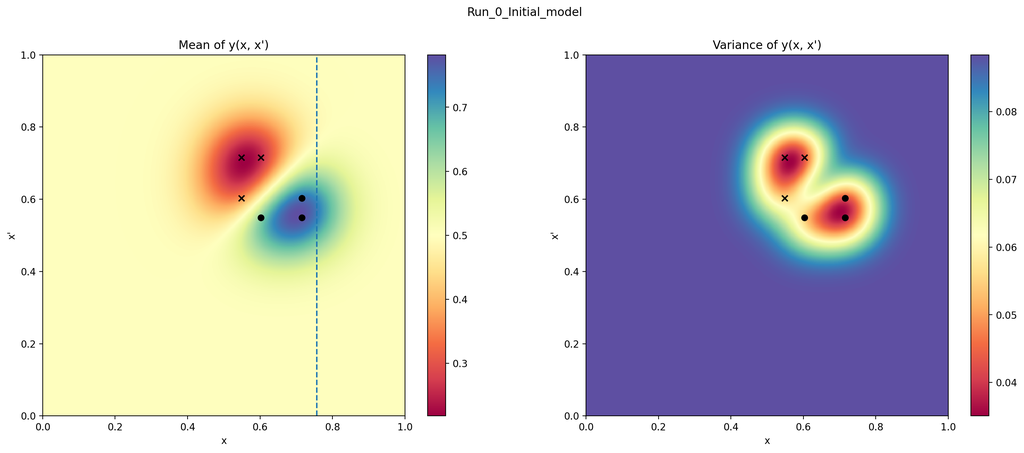

```python
## 初始化本轮模型

# 下面的这些变量名决定了绘制图片的titel，同时也是对实验任务的说明
objective_name = "Forrester"
acquisition_name = "DTS"
experiment_name = acquisition_name + "_" + objective_name          # 实验名称
results_dir = os.getcwd() + '/results/' + experiment_name + '/'    # 存储路径（上文已经注释掉存储到本地的代码，因此不会存储到本地）

# 选择模型使用的lengthscale，
lengthscale = lengthscale_mean_regularizer

model = train_and_visualize(X, y, lengthscale=lengthscale, title="Run_{}_Initial_model".format(run))
```

```python
# 查看当前各变量结果
print(X)
print(y)
print(combs)
print(model)
```

```
[[0.5488135  0.71518937]
 [0.5488135  0.60276338]
 [0.71518937 0.60276338]
 [0.71518937 0.5488135 ]
 [0.60276338 0.5488135 ]
 [0.60276338 0.71518937]]
[[0]
 [0]
 [1]
 [1]
 [1]
 [0]]
[[0.       0.      ]
 [0.       0.001001]
 [0.       0.002002]
 ...
 [1.       0.997998]
 [1.       0.998999]
 [1.       1.      ]]
<gpflow.models.svgp.SVGP object at 0x7ff0d0016a90>
```

### 4.5 每一轮的迭代部分

即：在初始化3个点后，再迭代20次，每次选取一个点，更新一次GP。

迭代次数由num_evals确定，这里选取的值为20. 通过下面的代码实现迭代：

```
for evaluation in range(num_evals):
    ...
```

**后面的部分就没运行了，报错显存不够，但代码应该是没问题的**

#### 4.5.1 随机傅里叶特征采样法

即RFF.

```python
## 随机傅里叶特征方法采样的实现
# 给出模型的W和b，根据X采样出模型对应的值

def fourier_features(X, W, b):
    """
    Given sampled tensors W and b, construct Fourier features of X. We do not take into account the normalizing constant
    alpha in this method as it is only used for optimization, and the constant does not affect the location of the
    maximizing point.
    :param X: tensor of shape (count, n, d)
    :param W: tensor of shape (count, D, d)
    :param b: tensor of shape (count, D, 1)
    :param kernel: gpflow kernel
    :return: tensor of shape (count, n, D)
    """
    D = W.shape[1]

    # tf.linalg.matrix_transpose(X)：Transposes last two dimensions of tensor X
    WX_b = W @ tf.linalg.matrix_transpose(X) + b  # (count, D, n)
    # RFF的计算公式即下式
    return tf.cast(tf.sqrt(2.0 / D), dtype=tf.float64) * tf.cos(tf.linalg.matrix_transpose(WX_b))  # (count, n, D)
```

```python
## 根据模型的kernel计算出模型的傅里叶采样特征W和b
# 返回输入X对应的查询值，以及模型特征W和b
# X应包括整个样本空间（要据此计算出count和d，如这里的X的长度应该是1000*1000）
# D为RFF中傅里叶特征的数量，默认为100

def sample_fourier_features(X, kernel, D=100):
    """
    Fourier feature mapping of X for the RBF kernel
    :param X: tensor of shape (count, n, d)
    :return: tensor of shape (count, n, D)
    """
    count = X.shape[0]           # 给出的样本点的数量
    d = X.shape[2]               # 样本点的维度

    if type(kernel) == gpflow.kernels.base.Product:  # For DTS implementation where we use a product of kernels
        # 如果kernel是通过product方法得到的，则按照下面的方法计算lengthscales
        input_dims = d // 2
        lengthscales = np.zeros(d)
        for i in range(input_dims):
            k = kernel.kernels[i]
            lengthscale_val = k.lengthscale.numpy()
            lengthscales[i] = lengthscale_val
            lengthscales[i + input_dims] = lengthscale_val
    else:
        lengthscales = kernel.lengthscale.numpy()

    # 计算模型的W和b
    W = tf.random.normal(shape=(count, D, d), mean=0.0, stddev=1.0 / lengthscales,dtype=tf.float64)
    b = tf.random.uniform(shape=(count, D, 1), minval=0, maxval=2 * np.pi, dtype=tf.float64)

    # 返回输入X对应的查询值，以及模型特征W和b
    return fourier_features(X, W, b), W, b  # (count, n, D)
```

```python
## 采样得到theta
# 采样公式：q(theta|D) = /int p(theta|y)p(y|f)q(f|D) df dy

def sample_theta_variational(phi, q_mu, q_sqrt):
    """
    Samples from distribution q(theta|D) = /int p(theta|y)p(y|f)q(f|D) df dy
    :param phi: Fourier features tensor with shape (count, n, D)
    :param q_mu: tensor of shape (n, 1)
    :param q_sqrt: tensor of shape (1, n, n). Lower triangular matrix
    :return: tensor with shape (count, D, 1)
    """
    count = phi.shape[0]
    n = phi.shape[1]
    D = phi.shape[2]

    standard_normal = tfp.distributions.MultivariateNormalDiag(
            loc=tf.zeros(n, dtype=tf.float64),
            scale_diag=tf.ones(n, dtype=tf.float64))
    standard_normal_samples = standard_normal.sample(count)
    # (count, n)

    q_samples = q_sqrt @ tf.expand_dims(standard_normal_samples, axis=-1) + q_mu
    # (count,n,1)

    transposed_phi = tf.linalg.matrix_transpose(phi)
    # (count, D, n)

    transform_mat = tf.cond(n >= D,
        true_fn = lambda : tf.linalg.inv(transposed_phi @ phi) @ transposed_phi,
        false_fn = lambda: transposed_phi @ tf.linalg.inv(phi @ transposed_phi) ) # (count, D, n)

    theta = transform_mat @ q_samples
    # (count, D, 1)

    return theta
```

#### 4.5.2 采样函数的定义

这里的采样是指从GP上采样，而不是从目标函数上采样。

```python
## 采样函数
# 根据模型m查询query_points的值，combs是duels的样本空间，有1000*1000种情况
# D为RFF中傅里叶特征的数量，默认为1000

def sample_f(m, query_points, combs, D=1000):
    """
    Generates a sample f using continuous Thompson sampling.
    :param m: gpflow model
    :param query_points: Input points corresponding to trained gpflow model. Tensor of shape (n, d)
    :param combs: tensor of shape (num_discrete_points ** 2, input_dims * 2). all combinations of discrete points
    :return: tensor of shape (num_discrete_points ** 2, 1)
    """
    # 这里的X已经不是每一轮的测试点，而是整个样本空间X
    X = np.expand_dims(combs, axis=0)

    # 根据GP模型的核函数计算出模型的傅里叶特征W和b，并返回所有X（整个样本空间）对应的GP观测值
    # 全部样本的观测值用phi存储，实际上phi即此刻GP给出的模拟值
    phi, W, b = sample_fourier_features(X, m.kernel, D)

    # 根据GP模型的傅里叶特征W和b，查询待查寻点query_points对应的值，记为phi_y
    phi_y = fourier_features(tf.expand_dims(query_points, axis=0), W, b)
    # 这里的m.q_mu和m.q_sqrt对应GPmodel的变分特性，由此计算出theta的值
    theta = sample_theta_variational(phi_y, m.q_mu, m.q_sqrt)

    # tf.squeeze删除维度为1的维度，给出最终的采样结果
    return tf.squeeze(phi @ theta, axis=0)
```

#### 4.5.3 计算本次迭代后得到GP给出的样本空间上的采样值（迭代step.1）

```python
evaluation = 0                                    # 迭代次数，in range(20)，这里假设为0
num_fourier_features = 200                        # RFF中傅里叶特征的数量
log("Starting evaluation " + str(evaluation))

# 使用随机傅里叶特征方法Random Fourier Features采样model，得到样本空间上每个点在本次GP上的采样值
f_vals = sample_f(model, X, combs, num_fourier_features)     # (num_discrete_points ** 2, 1)
```

#### 4.5.4 找出下一对duel（迭代step.2）

**定义Soft-Copeland函数**

```python
## 找出Condorcet winner的函数（即确定下一个duel的x点）
# 根据论文公式计算的

def soft_copeland_maximizer(f_vals, discrete_space):
    """
    Given function evaluations, calculate the Condorcet winner.
    :param f_vals: tensor of shape (num_discrete_points ** 2, 1)
    :param discrete_space: tensor of shape (num_discrete_points, input_dims). all discrete points
    """
    num_discrete_points = int(np.sqrt(f_vals.shape[0]))   # f_vals的shape是(num_discrete_points ** 2, 1)
    # 下面这句参见论文里的公式
    soft_copeland = np.mean(np.reshape(logistic(f_vals),
                                       [num_discrete_points, num_discrete_points]), axis=1)  # (num_discrete_points)
    return discrete_space[np.argmax(soft_copeland)]
```

**找出Condorcet winner**

```python
log("Computing acquisition function")

## 确定next duel中的x的值
# 其中discrete_space是离散化后x的定义域，为[0,1]均分1000
x_next = soft_copeland_maximizer(f_vals, discrete_space)

## 确定next duel中的x'的值
all_pairs = np.concatenate([np.tile(x_next, (discrete_space.shape[0], 1)), discrete_space], axis=1)
next_vars = np.squeeze(variance_logistic_f(model, all_pairs), axis=1)
xprime_next = discrete_space[np.argmax(next_vars)]

## 此即确定了next duel：[x,x']
x_xprime_next = np.expand_dims(np.concatenate([x_next, xprime_next]), axis=0)

## 下面这个处理是考虑到傅里叶特征的一些特性作出的一些处理
# Change by random small values otherwise Fourier features matrix becomes non-invertible
if np.all(np.equal(x_xprime_next, flip(x_xprime_next))) or x_xprime_next in X:
    for i in range(len(x_xprime_next[0])):
        if x_xprime_next[0][i] < 0:
            x_xprime_next[0][i] += np.random.uniform(low=0., high=1e-3)
        else:
            x_xprime_next[0][i] -= np.random.uniform(low=0., high=1e-3)

# 给出next duel
log("x and x_prime: \n" + str(x_xprime_next))
```

#### 4.5.5 根据acquisition确定的duel进行下一次观测（迭代step.3）

```python
# 观测AF确定的duel对应的偏好值
y_next = get_noisy_observation_dts(x_xprime_next, objective)
log("y_next: \n" + str(y_next))

# 更新数据集即X和y
X = np.vstack([X, x_xprime_next, flip(x_xprime_next)])
y = np.vstack([y, y_next, flip_y(y_next)])
# print(X)
# print(y)
```

#### 4.5.6 用更新后的数据拟合模型（迭代step.4）

```python
# 用新数据拟合本次迭代的模型model
model = train_and_visualize(X, y, lengthscale=lengthscale, title="Run_{}_Evaluation_{}".format(run, evaluation))
```

#### 4.5.7 存储模型数据（迭代step.5）

```python
# 记录下模型的variance和lengthscale
kernels_variance = []
kernels_lengthscale = []
for k in model.kernel.kernels:
    kernels_variance.append(k.variance.numpy())
    kernels_lengthscale.append(k.lengthscale.numpy())

## 将模型数据保存为本地文件
# pickle.dump((X, y,
#             tuple(kernels_variance),
#             tuple(kernels_lengthscale),
#             model.q_mu.numpy(),
#             model.q_sqrt.numpy()),
#             open(results_dir + "Model_Run_{}_Evaluation_{}.p".format(run, evaluation), "wb"))
```

#### 4.5.8 找出本轮迭代最偏好的点（迭代step.6）

```python
## 直接找出soft-copeland最优值即可
def best_guess(m, discrete_space, combs):
    return soft_copeland_maximizer(m.predict_y(combs)[0], discrete_space)
```

```python
# Get current best guess
best_guess_results[run, evaluation] = best_guess(model, discrete_space, combs)
```

### 4.6 记录本轮（20次）的迭代结果

```python
# 以轮为单位，记录20次迭代的结果
X_results[run] = X      # for run in range(10)
y_results[run] = y
```

## 五、输出结果

### 5.1 保存每轮迭代的数据

```python
# 将每轮迭代数据保存到文件
pickle.dump((X_results, y_results, best_guess_results), open(results_dir + "Xybestguess.p", "wb"))
```

### 5.2 保存每轮迭代的误差

```python
global_min = np.min(objective(discrete_space))       # 由目标函数算出的最值
metric = best_guess_results                          # 每轮给出的最好估计
ir = objective(metric) - global_min                  # 估计误差
mean = np.mean(ir, axis=0)                           # 计算均值
std_dev = np.std(ir, axis=0)                         # 计算标准偏差
std_err = std_dev / np.sqrt(ir.shape[0])             # 标准误差
```

```python
# 输出误差情况
print("Mean immediate regret at each evaluation averaged across all runs:")
print(mean)

print("Standard error of immediate regret at each evaluation averaged across all runs:")
print(std_err)
```

```python
# 保存误差情况
with open(results_dir + acquisition_name + "_" + objective_name + "_" + "mean_sem" + ".txt", "w") as text_file:
    print("Mean immediate regret at each evaluation averaged across all runs:", file=text_file)
    print(mean, file=text_file)
    print("Standard error of immediate regret at each evaluation averaged across all runs:", file=text_file)
    print(std_err, file=text_file)

pickle.dump((mean, std_err), open(results_dir + acquisition_name + "_" + objective_name + "_" + "mean_sem.p", "wb"))
```